# 面膜市场探索性分析

钟保罗 2019101155

2019-10-24

## 数据介绍

本数据集收集了共210家品牌共794种产品的月销量，该数据集包含了不同面膜的品牌、月销量、功效、评价数等数据。为了探究面膜销量与哪些因素有关，我们进行了相关的探索性分析。本数据集的具体变量如下：

| 变量类型 | 变量名 | 变量说明 | 取值范围 |
| --- | --- | --- | --- |
| 因变量 | 月销量 | 定量变量 | [0-49694] |
| 自变量 | 名称 | 定性变量 | ANGLEE/BF… |
| 自变量 | 价格 | 定量变量 | [12.85-1796] |
| 自变量 | 评价数 | 定量变量 | [0-405515] |
| 自变量 | 店铺所在地 | 定性变量 | 安徽、北京等 |
| 自变量 | 适合肤质 | 定性变量 | 干性肤质、油性肤质、中性肤质等 |
| 自变量 | 产地 | 定性变量 | 中国、韩国等 |
| 自变量 | 补水保湿 | 定性变量 | 1、0 |
| 自变量 | 美白提亮 | 定性变量 | 1、0 |
| 自变量 | 控油祛痘 | 定性变量 | 1、0 |
| 自变量 | 清洁毛孔 | 定性变量 | 1、0 |
| 自变量 | 提拉紧致 | 定性变量 | 1、0 |

## 数据分析

### 因变量分析

针对月销量我们可以看出，绝大多数的面膜销量集中在500以下，头部产品集中效应显著，。头部产品面膜占据市场份额较重，市场已发展几乎成熟，内部竞争激烈，腰部、尾部产品销量有较大发展潜力。

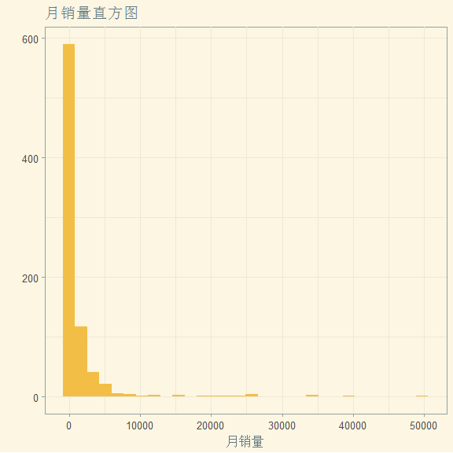

```r
data = read.csv("F:/大数据/大数据统计基础/面膜数据.csv")

library(ggthemes)
library(ggplot2)
p = ggplot(data = data ,aes(月销量)) + geom_histogram(fill = '#f2be45') +
  theme_solarized() + ggtitle("月销量直方图") + ylab('')
print(p)
```

### 自变量分析

#### 价格

从价格来看，面膜价格主要集中在250元以下，低价商品种类占据了面膜品类的大多数。 分价格区间看，不同价格区间的月销量均值随着价格升高有所下降，但下降不显著，未出现明显差异。 因为高价商品种类较少，然而月销量和低价商品未出现明显差异，说明高价商品市场竞争比低价商品市场更轻松，高价商品市场仍有进一步发展空间。

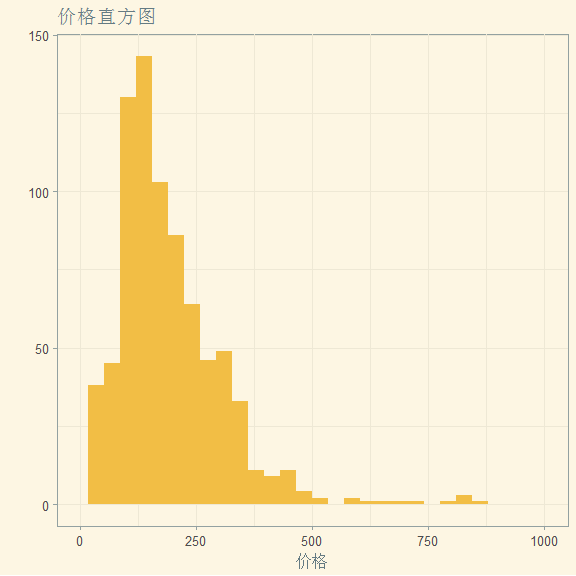

```r
#不同价格
p = ggplot(data = data ,aes(x = 价格)) + geom_histogram(fill = '#f2be45') + xlim(0,1000) +
  theme_solarized() + ggtitle("价格直方图") + ylab('')
print(p)
```

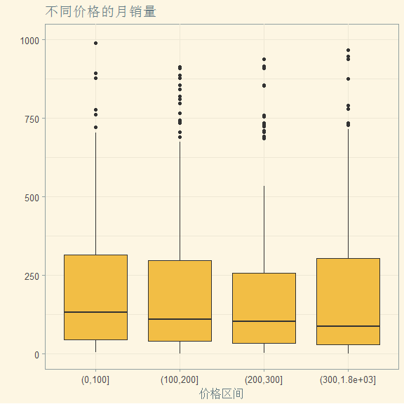

```r
cut_inter = c(0,100,200,300,max(data$价格))
data$价格区间 = cut(data$价格,cut_inter)
p = ggplot(data = data ,aes(x = 价格区间,y = 月销量)) + geom_boxplot(fill = '#f2be45') +
  theme_solarized() + ggtitle("不同价格的月销量") + ylab('')+ylim(0,1000)
print(p)
```

#### 评价数

月销量随着评价数的增长而有显著的增长，评价数和月销量是相互促进关系，月销量越高，评价数也会越多，而评价数越多，更会促进月销量增长。

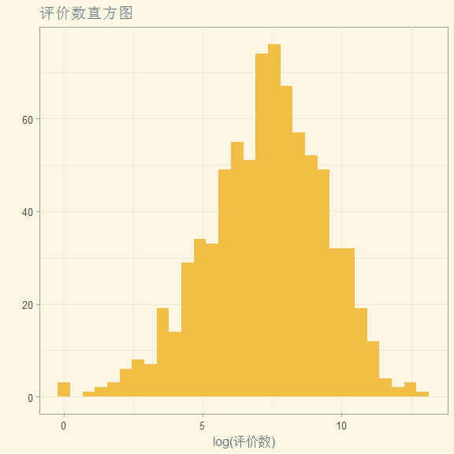

```r
#不同评价数
p = ggplot(data = data ,aes(x = log(评价数))) + geom_histogram(fill = '#f2be45') +
  theme_solarized() + ggtitle("评价数直方图") + ylab('') +xlab('log(评价数)')
print(p)
```

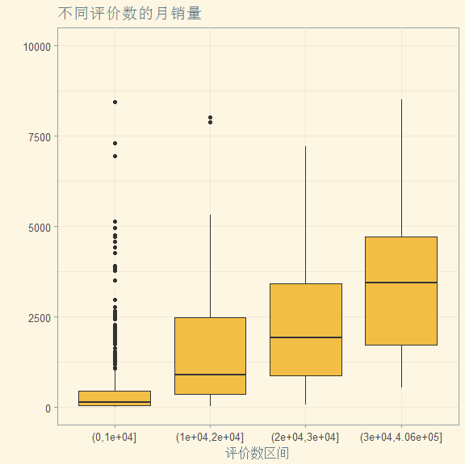

```r
cut_inter = c(0,10000,20000,30000,max(data$评价数))
data$评价数区间 = cut(data$评价数,cut_inter)
p = ggplot(data = data ,aes(x = 评价数区间,y = 月销量)) + geom_boxplot(fill = '#f2be45') +
  theme_solarized() + ggtitle("不同评价数的月销量") + ylab('')+ylim(0,10000)
print(p)
```

#### 功效

针对不同功效{‘补水保湿’,‘美白提亮’,‘控油祛痘’,‘清洁毛孔’,‘提拉紧致’}的面膜产品，主要面膜主要会开发“补水保湿”功效的面膜产品，“提拉紧致”的面膜产品相对较少，然而销量相对更大的是“控油祛痘”类面膜。

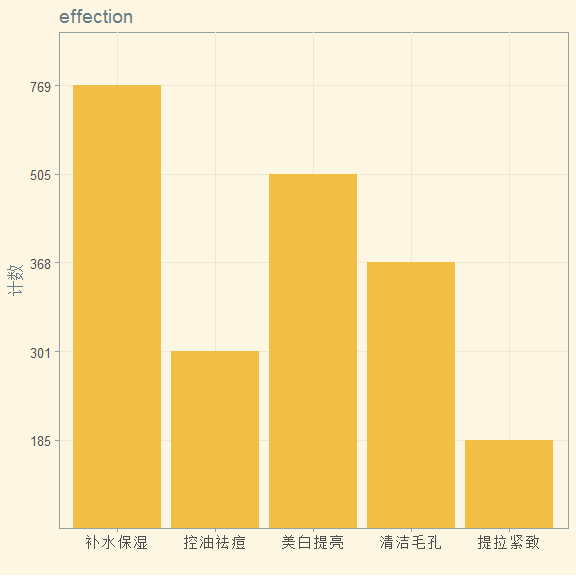

```r
#不同功能
table_name = c('补水保湿','美白提亮','控油祛痘','清洁毛孔','提拉紧致')
table_sum = c(sum(data['补水保湿']),sum(data['美白提亮']),
sum(data['控油祛痘']),sum(data['清洁毛孔']),
sum(data['提拉紧致']))
data_table = data.frame(cbind(table_name,table_sum))
p = ggplot(data = data_table ,aes(x = table_name,y = table_sum)) + geom_bar(stat = "identity",fill = '#f2be45') +
  theme_solarized() + ggtitle("effection") + xlab('') + ylab('计数')
print(p)
```

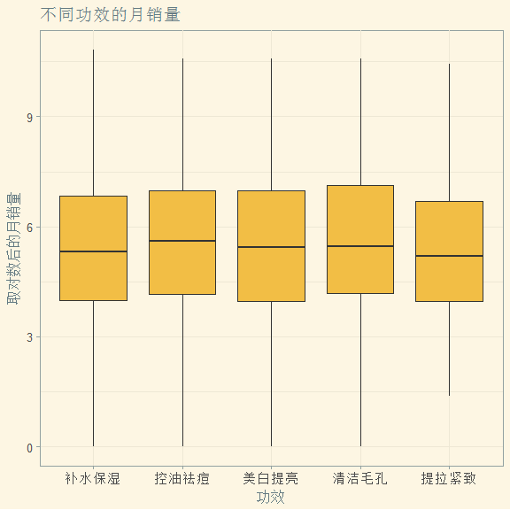

```r
data1 = cbind('补水保湿',data$月销量[data$补水保湿==1])
data2 = cbind('美白提亮',data$月销量[data$美白提亮==1])
data3 = cbind('控油祛痘',data$月销量[data$控油祛痘==1])
data4 = cbind('清洁毛孔',data$月销量[data$清洁毛孔==1])
data5 = cbind('提拉紧致',data$月销量[data$提拉紧致==1])
data_new = rbind(data1,data2,data3,data4,data5)
data_new = data.frame(data_new)
colnames(data_new) = c('功效','月销量')
data_new$月销量 = as.numeric(as.character(data_new$月销量))
p = ggplot(data = data_new ,aes(x = 功效,y = log(月销量))) + geom_boxplot(fill = '#f2be45') +
  theme_solarized() + ggtitle("不同功效的月销量") + ylab('取对数后的月销量')#+ylim(0,10)
print(p)
```

#### 店铺所在地的月销量

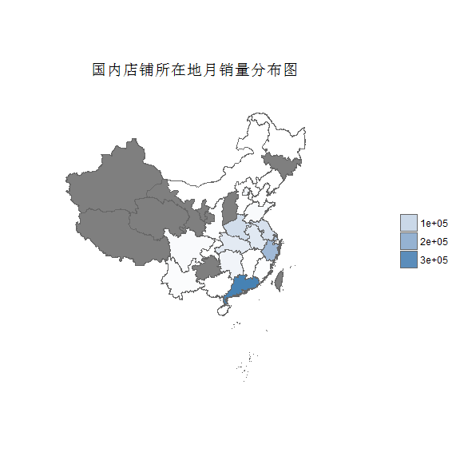

```r
#不同产地
library(maps)
library(mapdata)
library(maptools)
library(stringr)
china_map = readShapePoly("F:/大数据/大数据统计基础/bou2_4p.shp")
x <- china_map@data         #读取行政信息
xs <- data.frame(x,id=seq(0:924)-1)        #含岛屿共925个形状
xs$NAME1<-iconv(xs$NAME,"GBK","UTF-8")  #新建列，改变乱码编码
xs$NAME1<-str_replace(xs$NAME1,"省","")
xs$NAME1<-str_replace(xs$NAME1,"特别行政区","")
xs$NAME1<-str_replace(xs$NAME1,"自治区","")
xs$NAME1<-str_replace(xs$NAME1,"维吾尔","")
xs$NAME1<-str_replace(xs$NAME1,"回族","")
xs$NAME1<-str_replace(xs$NAME1,"壮族","")
xs$NAME1<-str_replace(xs$NAME1,"市","")
china_map1 <- fortify(china_map)          #转化为数据框
data_place = aggregate(data[,c('月销量')],by=list(NAME1=data$店铺所在地),FUN=sum)
library(plyr)
china_map_data <- join(china_map1, xs, type = "full")
data_place = data_place[-c(7,22,23),]
china_data = join(china_map_data, data_place, type="full")
ggplot(china_data, aes(x = long, y = lat, group = group,fill = china_data$x)) +
  geom_polygon(colour="grey40") +
  scale_fill_gradient(low="white",high="steelblue") +  #指定渐变填充色，可使用RGB
  coord_map("polyconic") +     #指定投影方式为polyconic，获得常见视角中国地图
  theme(             #清除不需要的元素
    panel.grid = element_blank(),
    panel.background = element_blank(),
    axis.text = element_blank(),
    axis.ticks = element_blank(),
    axis.title = element_blank(),
    title=element_text(family="STKaiti",size=12,color="black"),plot.title = element_text(hjust = 0.5)
  )+guides(fill=guide_legend(title=NULL))+ggtitle('国内店铺所在地月销量分布图')
```